# Analyzing hurricane tracks

## Exploratory data analysis

In this section we perform exploratory analysis of the dataset and answer some interesting questions.

```python
map1 = gis.map('USA')
map1
```

[figure not shown]

```python
all_hurricanes_df.sample(n=500, random_state=2).spatial.plot(map1,
                                                             renderer_type='u',
                                                             col='ANY_Basin',
                                                            cmap='prism')
```

```
True
```

The map above draws a set of `500` hurricanes chosen at random. You can visualize the Spatially Enabled DataFrame object with different types of renderers. In the example above a unique value renderer is applied on the **basin** column. You can switch the map to 3D mode and view the same on a globe.

[figure not shown]

```python
map1.mode = '3D'
```

### Does the number of hurricanes increase with time?

To understand if number of hurricanes have increased over time, we plot a histogram of the `MIN_Season` column.

```
Text(0.5,1,'Number of hurricanes recorded over time')
```

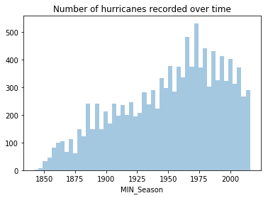

```python
ax = sns.distplot(all_hurricanes_df['MIN_Season'], kde=False, bins=50)
ax.set_title('Number of hurricanes recorded over time')
```

The number of hurricanes recorded increases steadily until `1970`. This could be due to advances in geospatial technologies allowing scientists to better monitor hurricanes. However, after `1970` we notice a reduction in the number of hurricanes. This is in line with what [scientists observe and predict](https://www.nytimes.com/2018/10/10/climate/hurricane-michael-climate-change.html).

```python
from IPython.display import HTML
HTML('<iframe width="560" height="315" src="https://www.nytimes.com/2018/10/10/climate/hurricane-michael-climate-change.html" frameborder="0" allowfullscreen></iframe>')
```

[interactive chart not shown]

### How many hurricanes occuer per basin and sub basin?

About `7` basins and a number of sub basins have been identified. The snippet below plots the frequency of hurricanes by basin and sub basin.

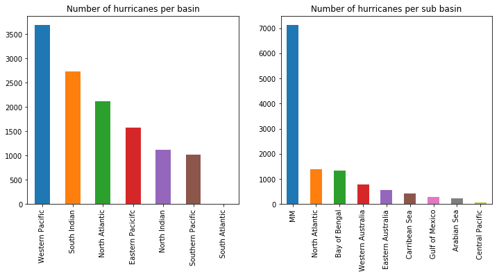

```python
fig1, ax1 = plt.subplots(1,2, figsize=(12,5))

basin_ax = all_hurricanes_df['ANY_Basin'].value_counts().plot(kind='bar', ax=ax1[0])
basin_ax.set_title('Number of hurricanes per basin')
# basin_ax.tick_params(axis='x', labelrotation=65)
basin_ax.set_xticklabels(['Western Pacific', 'South Indian', 'North Atlantic',
                          'Eastern Pacicifc', 'North Indian','Southern Pacific',
                          'South Atlantic'])

sub_basin_ax = all_hurricanes_df['ANY_Sub_basin'].value_counts().plot(kind='bar', ax=ax1[1])
sub_basin_ax.set_title('Number of hurricanes per sub basin')
sub_basin_ax.set_xticklabels(['MM','North Atlantic','Bay of Bengal','Western Australia',
                             'Eastern Australia', 'Carribean Sea', 'Gulf of Mexico',
                             'Arabian Sea', 'Central Pacific'])
sub_basin_ax.tick_params()
```

Thus, most hurricanes occur in **Wester Pacific** basin. This is the region that is east of China, Phillipines and rest of South East Asia. This is followed by **South Indian** which spans from west of Australia to east of Southern Africa. **North Atlantic** basin which is the source of hurricanes in the continental United States ranks as the third busiest hurricane basin.

### Are certain hurricane names more popular?

```python
# Get the number of occurrences of top 25 hurricane names
all_hurricanes_df['ANY_Name'].value_counts()[:25]
```

```
NOT NAMED          4096
UNNAMED            1408
06B                  31
04B                  30
05B                  30
09B                  30
08B                  29
10B                  29
07B                  29
03B                  28
01B                  27
12B                  26
13B                  23
11B                  23
02B                  22
14B                  17
SUBTROP:UNNAMED      16
FLORENCE             15
IRMA                 15
02A                  14
DOT                  13
FREDA                13
OLGA                 13
JUNE                 13
KATE                 13
Name: ANY_Name, dtype: int64
```

Names like `FLORENCE`, `IRMA`, `OLGA`.. appear to be more popular. Interestingly all are of female gender. When have the name `FLORENCE` been used?

```python
all_hurricanes_df[all_hurricanes_df['ANY_Name']=='FLORENCE'].index
```

```
DatetimeIndex(['1954-09-10', '1953-09-23', '1960-09-17', '1965-09-08',
               '1963-07-14', '1964-09-05', '1967-01-03', '1969-09-02',
               '1973-07-25', '1977-09-20', '1988-09-07', '1994-11-02',
               '2000-09-10', '2006-09-03', '2012-08-03'],
              dtype='datetime64[ns]', name='START_DATETIME', freq=None)
```

### Is there a seasonality in the occurrence of hurricanes?

Hurricanes happen when water temperatures (`Sea Surface Temperature` SST) are warm. Solar incidence is one of the key factors affecting SST and this typically happens during summer months. However, summer happens during different months in northern and southern hemispheres. To visualize this seasonality, we need to group our data by month as well as basin. Thus the snippet below creates a multilevel index grouper in Pandas

```python
# Create a grouper object
grouper = all_hurricanes_df.START_DATETIME.dt.month_name()

# use grouper along with basin name to create a multilevel groupby object
hurr_by_basin = all_hurricanes_df.groupby([grouper,'ANY_Basin'], as_index=True)
hurr_by_basin_month = hurr_by_basin.count()[['COUNT_', 'MIN_pressure_m']]
hurr_by_basin_month.head()
```

| START_DATETIME | ANY_Basin | COUNT_ | MIN_pressure_m |
| --- | --- | --- | --- |
| April | NA | 5 | 5 |
|  | NI | 41 | 41 |
|  | SI | 241 | 241 |
|  | SP | 93 | 93 |
|  | WP | 82 | 82 |

Now we turn the index into columns. Then add the month column back, but this time we will help Pandas understand how to sort months other than by alphabetical order.

```python
# turn index into columns
hurr_by_basin_month.reset_index(inplace=True)
hurr_by_basin_month.drop('MIN_pressure_m', axis=1, inplace=True)
hurr_by_basin_month.columns = ['month', 'basin', 'count']
hurr_by_basin_month.head()
```

|  | month | basin | count |
| --- | --- | --- | --- |
| 0 | April | NA | 5 |
| 1 | April | NI | 41 |
| 2 | April | SI | 241 |
| 3 | April | SP | 93 |
| 4 | April | WP | 82 |

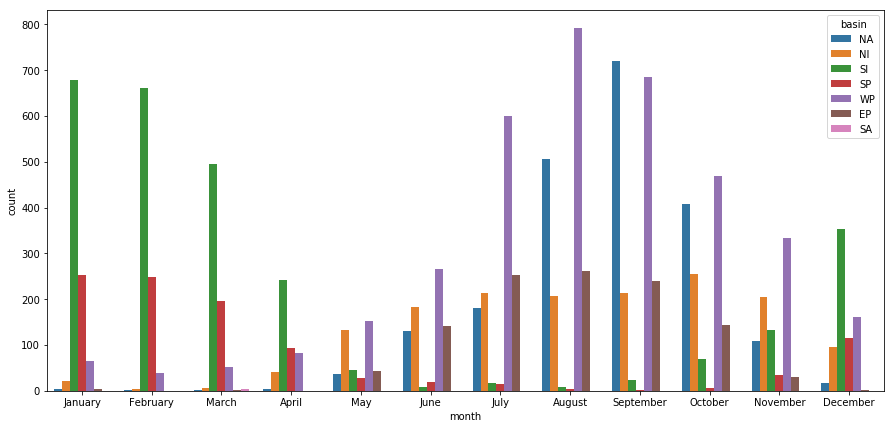

```python
fig, ax = plt.subplots(1,1, figsize=(15,7))
month_order = ['January','February', 'March','April','May','June',
              'July','August','September','October','November','December']

sns.barplot(x='month', y='count', hue='basin', data=hurr_by_basin_month, ax=ax,
            order=month_order)
```

The bars in **green** represent the number of hurricanes in **Sounth Indian** ocean which spans from west of Australia to east of southern Africa while the **purple** bars are for **Western Pacific** which spans east of China and **blue** bars for **North Atlantic**. The sinusoidal nature of these bars show the charateristic offset in summer between northern and southern hemispheres. The **orange** bars represent **North Indian** hurricanes which is dominated by monsoon effect and is seen to be prevalant for most part of the year.

### What are the hurricanes that traveled the longest distance?

```
Text(0.5,1,'Distribution of hurricane track lengths')
```

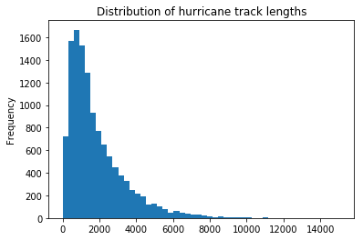

```python
ax = all_hurricanes_df['TRACK_length_mi'].plot(kind='hist', bins=50)
ax.set_title('Distribution of hurricane track lengths')
```

```python
longest_10_hurricanes = all_hurricanes_df[['ANY_Name', 'TRACK_length_mi',
                                        'SHAPE', 'ANY_Basin']].sort_values(
    by='TRACK_length_mi', ascending=False)[:10]

longest_10_hurricanes[['ANY_Name', 'TRACK_length_mi', 'ANY_Basin']]
```

| START_DATETIME | ANY_Name | TRACK_length_mi | ANY_Basin |
| --- | --- | --- | --- |
| 1951-09-29 | HOW | 15077.798637 | NA |
| 2013-08-12 | UNALA | 12516.900194 | EP |
| 1932-08-30 | UNNAMED | 11953.755801 | NA |
| 2000-08-03 | ALBERTO | 11745.655294 | NA |
| 1956-02-16 | 22S:UNNAMED | 11455.153802 | SI |
| 1955-09-10 | IONE | 11133.714424 | NA |
| 1966-08-21 | FAITH | 11062.052830 | NA |
| 1992-01-26 | EKEKA | 10978.776098 | EP |
| 1899-08-03 | UNNAMED | 10253.111098 | NA |
| 1900-08-27 | UNNAMED | 10209.338029 | NA |

`7` of the `10` longest hurricanes have occurred in **North Atlantic**. We can easily plot that on the map to visualize.

```python
longest_map = gis.map()
longest_map
```

[figure not shown]

```python
longest_10_hurricanes.spatial.plot(longest_map, renderer_type='u',
                                   col='ANY_Basin', cmap='prism')
```

```
True
```

```python
agol = GIS()
```

```python
world_boundaries_item = agol.content.get('2b93b06dc0dc4e809d3c8db5cb96ba69')
world_boundaries_item
```

[figure not shown]

[**World Countries (Generalized)**](https://www.arcgis.com/home/item.html?id=2b93b06dc0dc4e809d3c8db5cb96ba69)  
World Countries (Generalized) is a generalized layer of country level boundaries which can be used at small to medium scales. This layer is available at no cost to users with an ArcGIS Online subscription.

[figure not shown]

Feature Layer Collection by esri_dm  
Last Modified: October 09, 2018  
3 comments, 1,057,364 views

```python
boundary_fl = world_boundaries_item.layers[0]
from arcgis.features.manage_data import overlay_layers
```

```python
%%time
landfall_item = overlay_layers(input_layer=hurricane_fl, overlay_layer = boundary_fl,
                               overlay_type='Intersect', output_type='POINT',
                               output_name='hurricane_landfall_locations', gis=gis)
```

```
CPU times: user 33.8 s, sys: 2.99 s, total: 36.8 s
Wall time: 3h 6min 42s
```

```python
landfall_item
```

[figure not shown]

[**hurricane_landfall_locations**](https://geosaurus.maps.arcgis.com/home/item.html?id=5f9b82abeb494716a7886e338fb4b62b)

[figure not shown]

Feature Layer Collection by amani_geosaurus  
Last Modified: October 28, 2018  
0 comments, 0 views

```python
inland_tracks = overlay_layers(input_layer=hurricane_fl, overlay_layer = boundary_fl,
                               overlay_type='Intersect', output_type='Input',
                               output_name='hurricane_landfall_tracks', gis=gis)
```

## Manage missing sesnsor data

Sensor measurements such as **wind speed**, **atmospheric pressure**, **eye diameter**, suffer from missing values and outliers.

```python
all_hurricanes_df.shape
```

```
(12256, 19)
```

### Visualize missing records

An easy way to visualize missing records is to hack the `heatmap` of `seaborn` library to display missing records. The snippet below shows missing records in **yellow** color.

```
Text(0.5,1,'Missing values (yellow) visualized as a heatmap')
```

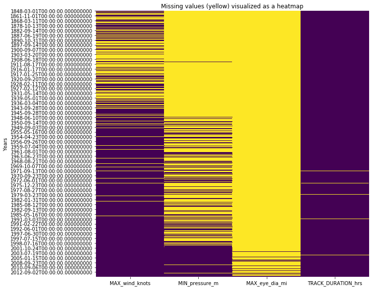

```python
missing_data_viz = all_hurricanes_df.replace(0,np.NaN)

plt.figure(figsize=(10,10))
missing_data_ax = sns.heatmap(missing_data_viz[['MAX_wind_knots',
                                 'MIN_pressure_m','MAX_eye_dia_mi',
                                 'TRACK_DURATION_hrs']].isnull(), cbar=False,
                             cmap='viridis')
missing_data_ax.set_ylabel('Years')
missing_data_ax.set_title('Missing values (yellow) visualized as a heatmap')
```

### Missing value imputation

**Technique 1: Drop missing values**

```python
hurricanes_nona = missing_data_viz.dropna(subset=['MAX_wind_knots','MIN_pressure_m'])
hurricanes_nona.shape
```

```
(3352, 19)
```

**Technique 2: Fill using median value**

```python
fill_values = {'MAX_wind_knots': missing_data_viz['MAX_wind_knots'].median(),
                'MIN_pressure_m': missing_data_viz['MIN_pressure_m'].median(),
              'TRACK_DURATION_hrs': missing_data_viz['TRACK_DURATION_hrs'].median()}
hurricanes_fillna = missing_data_viz.fillna(value=fill_values)
```

**Technique 3: Fill by interpolating between existing values**

```python
hurricanes_ipl = missing_data_viz
hurricanes_ipl['MAX_wind_knots'] = hurricanes_ipl['MAX_wind_knots'].interpolate()
hurricanes_ipl['MIN_pressure_m'] = hurricanes_ipl['MIN_pressure_m'].interpolate()
hurricanes_ipl['TRACK_DURATION_hrs'] = hurricanes_ipl['TRACK_DURATION_hrs'].interpolate()
```

**Visualize all 3 techniques**

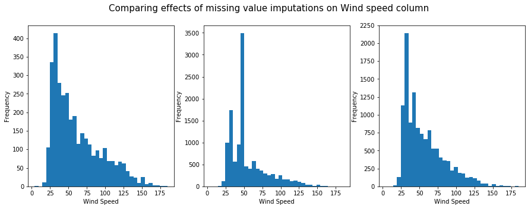

```python
fig, ax = plt.subplots(1,3, sharex=True, figsize=(15,5))
fig.suptitle('Comparing effects of missing value imputations on Wind speed column',
             fontsize=15)

hurricanes_nona['MAX_wind_knots'].plot(kind='hist', ax=ax[0], bins=35)
hurricanes_fillna['MAX_wind_knots'].plot(kind='hist', ax=ax[1], bins=35)
hurricanes_ipl['MAX_wind_knots'].plot(kind='hist', ax=ax[2], bins=35)
for a in ax:
    a.set_xlabel('Wind Speed')
```

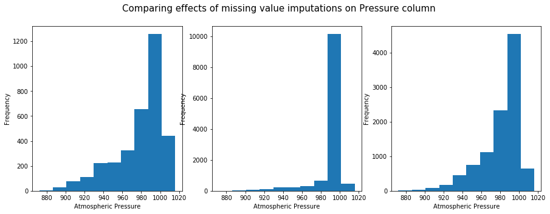

```python
fig, ax = plt.subplots(1,3, sharex=True, figsize=(15,5))
fig.suptitle('Comparing effects of missing value imputations on Pressure column',
             fontsize=15)

hurricanes_nona['MIN_pressure_m'].plot(kind='hist', ax=ax[0])
hurricanes_fillna['MIN_pressure_m'].plot(kind='hist', ax=ax[1])
hurricanes_ipl['MIN_pressure_m'].plot(kind='hist', ax=ax[2])
for a in ax:
    a.set_xlabel('Atmospheric Pressure')
```

Fill using **interpolation preserves shape** of the original distribution. So it will be used

```
Text(0.5,1,'Missing values (yellow) visualized as a heatmap')
```

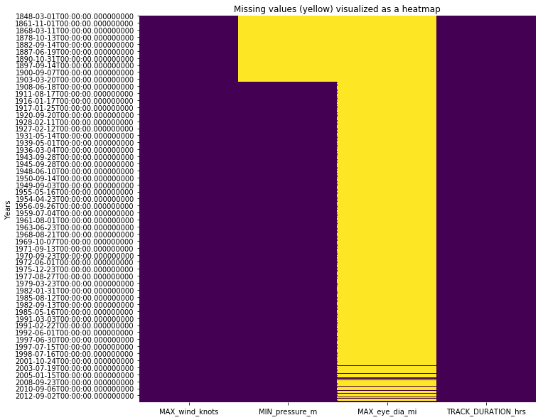

```python
plt.figure(figsize=(10,10))
missing_data_ax = sns.heatmap(hurricanes_ipl[['MAX_wind_knots',
                                 'MIN_pressure_m','MAX_eye_dia_mi',
                                 'TRACK_DURATION_hrs']].isnull(), cbar=False, cmap='viridis')
missing_data_ax.set_ylabel('Years')
missing_data_ax.set_title('Missing values (yellow) visualized as a heatmap')
```

# Does intensity of hurricanes increase over time?

```python
type(hurricanes_ipl['START_DATETIME'].head(1)[0])
```

```
pandas._libs.tslibs.timestamps.Timestamp
```

```python
hurricanes_ipl[['START_DATETIME','END_DATETIME']].head(5)
```

| START_DATETIME | START_DATETIME | END_DATETIME |
| --- | --- | --- |
| 1848-03-01 | 1848-03-01 | 1848-03-03 |
| 1851-10-16 | 1851-10-16 | 1851-10-19 |
| 1848-04-21 | 1848-04-21 | 1848-04-26 |
| 1848-01-11 | 1848-01-11 | 1848-01-13 |
| 1845-12-02 | 1845-12-02 | 1845-12-05 |

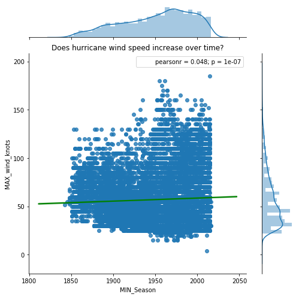

```python
jgrid = sns.jointplot(x='MIN_Season', y='MAX_wind_knots', data=hurricanes_ipl,
             kind='reg', joint_kws={'line_kws':{'color':'green'}}, height=7, space=0.5)
j = jgrid.annotate(stats.pearsonr)
j = jgrid.ax_joint.set_title('Does hurricane wind speed increase over time?')
```

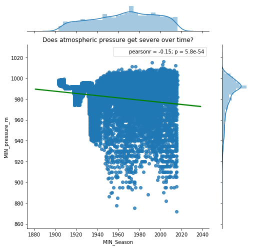

```python
jgrid = sns.jointplot(x='MIN_Season', y='MIN_pressure_m', data=hurricanes_ipl,
             kind='reg', joint_kws={'line_kws':{'color':'green'}}, height=7, space=0.5)
j = jgrid.annotate(stats.pearsonr)
j = jgrid.ax_joint.set_title('Does atmospheric pressure get severe over time?')
```

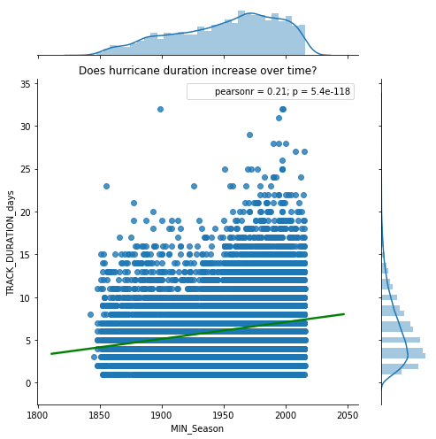

```python
jgrid = sns.jointplot(x='MIN_Season', y='TRACK_DURATION_days', data=hurricanes_ipl,
             kind='reg', joint_kws={'line_kws':{'color':'green'}}, height=7, space=0.5)
j = jgrid.annotate(stats.pearsonr)
j = jgrid.ax_joint.set_title('Does hurricane duration increase over time?')
```

### Do hurricanes linger longer over time?

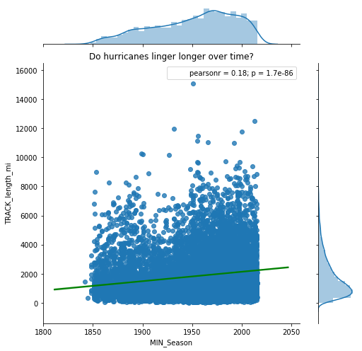

```python
jgrid = sns.jointplot(x='MIN_Season', y='TRACK_length_mi', data=all_hurricanes_df,
             kind='reg', joint_kws={'line_kws':{'color':'green'}}, height=7, space=0.5)
j = jgrid.annotate(stats.pearsonr)
j = jgrid.ax_joint.set_title('Do hurricanes linger longer over time?')
```